# SOLUCIONES taller en grupo Mat3 GIN 2025-2026

Autor/a

Michael Arias, Ana Gener, Laia Lluch, Arión Sintes

# Instrucciones para el taller

Se entrega en grupos que deben de estar constituidos en la actividad de grupos. Los grupos son de 2 o 3 ESTUDIANTES, loa caso especiales consultadlos con el profesor para que los autorice.

**Enlaces y Bibliografía**

- [R for data science, Hadley Wickham, Garret Grolemund.](https://r4ds.had.co.nz/)
- [Fundamentos de ciencia de datos con R.](https://cdr-book.github.io/)
- [Tablas avanzadas: kable, KableExtra.](https://haozhu233.github.io/kableExtra/awesome_table_in_html.html)
- [Geocomputation with R, Robin Lovelace, Jakub Nowosad, Jannes Muenchow](https://r.geocompx.org/)
- Apuntes de R-basico y tidyverse moodel MAT3.

## Objetivo MALLORCA

Leeremos los siguientes datos de la zona de etiqueta `mallorca` con el código siguiente:

**Código**

```r
load("clean_data/mallorca/listing_common0.RData")
ls()
```

```
[1] "listings_common0"
```

**Código**

```r
listings0 = listings_common0 %>%
  select(id, scrape_id, listing_url,
         neighbourhood_cleansed, price,
         number_of_reviews,
         review_scores_rating,
         review_scores_rating,
         review_scores_cleanliness,
         review_scores_location,
         review_scores_value,
         number_of_reviews,
         accommodates,
         bathrooms_text,
         bedrooms,
         beds,
         minimum_nights,
         description,
         latitude,
         longitude,
         property_type,
         room_type)
```

**listings**

Generamos la tibble `listings0` con datos DE 8 periodos DE apartamentos de inside Airbnb de Mallorca Y seleccionando cuantas variables nos parecen más interesantes.

Separararemos la fecha del scrapping que es en la que se observaron los datos de cada apartamento nos quedaremos con los apartamentos que aparecen en las 8 periodos “scrapeados”.

**Código**

```r
listings0= listings0 %>%
  mutate(date=as.Date(substr(
    as.character(scrape_id),1,8),
    format="%Y%m%d"),
    .after=id)
```

Ahora analizamos las fechas de los scrapings y el número de veces que aparecen cada apartamentos.

**Código**

```r
table(listings0$date)
```

```
2023-12-17 2024-03-23 2024-06-19 2024-09-13 2024-12-14 2025-03-07 2025-06-15
      9197       9197       9197       9197       9197       9197       9197
2025-09-21
      9197
```

Hay 8 periodos de scrapping y vamos a quedarnos con los apartamentos que aparecen en todos los periodos

Vemos que cada apartamento aparece 8 veces una por periodo.

**Código**

```r
table(table(listings0$id))
```

```
   8
9197
```

Notemos que cada apartamento:

- queda identificado por id y por date que nos da el periodo en la que apareció el dato.
- así que cada apartamento aparece 8 veces ya que hemos elegido solo los apartamentos que aparecen en las 8 muestras.
- Las muestras son 2023-12-17, 2024-03-23, 2024-06-19, 2024-09-13, 2024-12-14, 2025-03-07, 2025-06-15, 2025-09-21,

**Código**

```r
unique(listings0$date)
```

```
[1] "2023-12-17" "2024-03-23" "2024-06-19" "2024-09-13" "2024-12-14"
[6] "2025-03-07" "2025-06-15" "2025-09-21"
```

**reviews**

Estos datos necesitan leerse de forma adecuada, las columnas 1, 2 y 4 deben ser de tipo `character` las otras son correctas

**Código**

```r
reviews=read_csv("data/mallorca/2025-09-21/reviews.csv.gz")
str(reviews)
```

```
spc_tbl_ [398,782 × 6] (S3: spec_tbl_df/tbl_df/tbl/data.frame)
 $ listing_id   : num [1:398782] 69998 69998 69998 69998 69998 ...
 $ id           : num [1:398782] 881474 4007103 4170371 4408459 4485779 ...
 $ date         : Date[1:398782], format: "2012-01-24" "2013-04-02" ...
 $ reviewer_id  : num [1:398782] 1595616 3868130 5730759 5921885 810469 ...
 $ reviewer_name: chr [1:398782] "Jean-Pierre" "Jo And Mike" "Elizabeth" "Jone" ...
 $ comments     : chr [1:398782] "This place was charming! Lorenzo himself is a very warm and engaging host and made us feel very welcome. \r<br/"| __truncated__ "We had a four night stay at this gorgeous apartment and it was absolutely perfect. It's really pretty, beautifu"| __truncated__ "Lor's ap…
 - attr(*, "spec")=
  .. cols(
  ..   listing_id = col_double(),
  ..   id = col_double(),
  ..   date = col_date(format = ""),
  ..   reviewer_id = col_double(),
  ..   reviewer_name = col_character(),
  ..   comments = col_character()
  .. )
 - attr(*, "problems")=<externalptr>
```

**Código**

```r
head(reviews)
```

```
# A tibble: 6 × 6
  listing_id      id date       reviewer_id reviewer_name comments
       <dbl>   <dbl> <date>           <dbl> <chr>         <chr>
1      69998  881474 2012-01-24     1595616 Jean-Pierre   "This place was charm…
2      69998 4007103 2013-04-02     3868130 Jo And Mike   "We had a four night …
3      69998 4170371 2013-04-15     5730759 Elizabeth     "Lor's apartment look…
4      69998 4408459 2013-05-03     5921885 Jone          "Wonderful place! 10/…
5      69998 4485779 2013-05-07      810469 Andrea        "My boyfriend and I, …
6      69998 4619699 2013-05-15     3318059 Devii         "We had a very last m…
```

**neighbourhoods.csv**

Son dos columnas y la primera es una agrupación de municipios (están NA) y la segunda es el nombre del municipio

**Código**

```r
municipios=read_csv("data/mallorca/2025-09-21/neighbourhoods.csv")
str(municipios)
```

```
spc_tbl_ [53 × 2] (S3: spec_tbl_df/tbl_df/tbl/data.frame)
 $ neighbourhood_group: logi [1:53] NA NA NA NA NA NA ...
 $ neighbourhood      : chr [1:53] "Alaró" "Alcúdia" "Algaida" "Andratx" ...
 - attr(*, "spec")=
  .. cols(
  ..   neighbourhood_group = col_logical(),
  ..   neighbourhood = col_character()
  .. )
 - attr(*, "problems")=<externalptr>
```

**Código**

```r
head(municipios)
```

```
# A tibble: 6 × 2
  neighbourhood_group neighbourhood
  <lgl>               <chr>
1 NA                  Alaró
2 NA                  Alcúdia
3 NA                  Algaida
4 NA                  Andratx
5 NA                  Ariany
6 NA                  Artà
```

**neighbourhoods.geojson**

Es el mapa de Mallorca, o podemos leer así:

**Código**

```r
library(sf)
library(tmap)

# Leer el archivo GeoJSON
geojson_sf <- sf::st_read("data/mallorca/2025-09-21/neighbourhoods.geojson")
```

**Código**

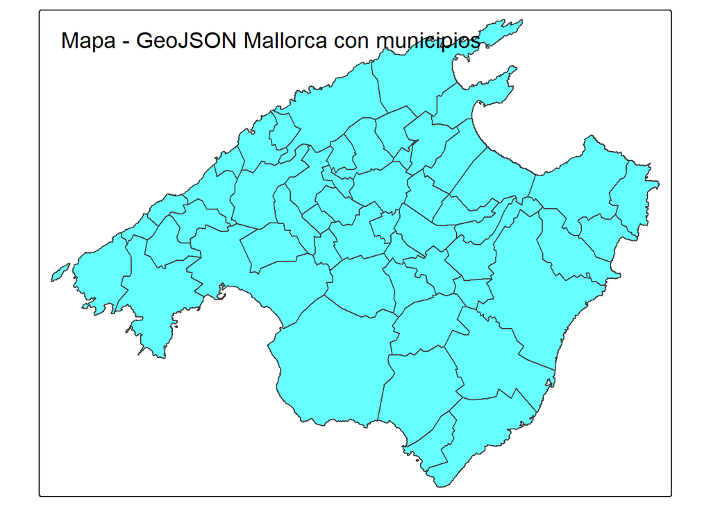

```r
# Crear un mapa

# interactivo
tmap_mode("plot") # Cambiar a modo  view/plot   que es interactivo/estático
tm_shape(geojson_sf) +
  tm_polygons(col = "cyan", alpha = 0.6) +
  tm_layout(title = "Mapa - GeoJSON Mallorca con municipios")
```

Tenéis que consultar en la documentación de inside Airbnb para saber que significa cada variable. Os puede ser útil leer los ficheros DATA_ABB_modelo_de_datos.html y DATA_ABB_modelo_de_datos.pdf en los que se explica el modelo de datos de inside Airbnb y como se cargan en el espacio de trabajo.

Responder las siguientes preguntas con formato Rmarkdown (.Rmd) o quarto (.qmd) y entregad la fuente un fichero en formato html como salida del informe. Se puntúa la claridad de la respuesta, la calidad de la redacción y la corrección de la respuesta.

## Pregunta 1 (**1punto**)

Del fichero con los datos de listings `listings0` calcula los estadísticos descriptivos de las variable `price` y de la variable `number_of_reviews` agrupados por municipio y por periodo.

Presenta los resultados con una tabla de kableExtra.

### SOLUCIÓN

Obtenemos los siguientes estadísticos descriptivos tanto del precio como del número de reseñas mediante la función summarise y mostramos las primeras filas de la tabla:

- Número de muestras $n$: es la cantidad de apartamentos disponibles en el municipio durante ese período.
- Media: precio medio de los apartamentos o número medio de reseñas según el municipio y el período.
- Desviación estándar: dispersión de precio o número de reseñas respecto a la media según el municipio y el período.

**Código**

```r
estadisticos <- listings0 %>%
  group_by(neighbourhood_cleansed, date) %>%
  summarise(
    Numero=n(),
    mean_price = mean(price, na.rm = TRUE),
    sd_price = sd(price, na.rm = TRUE),
    mean_reviews = mean(number_of_reviews, na.rm = TRUE),
    sd_reviews = sd(number_of_reviews, na.rm = TRUE)
  ) %>%
  ungroup()
head(estadisticos)
```

```
# A tibble: 6 × 7
  neighbourhood_cleansed date       Numero mean_price sd_price mean_reviews
  <chr>                  <date>      <int>      <dbl>    <dbl>        <dbl>
1 Alaró                  2023-12-17     62       425.     884.         39.1
2 Alaró                  2024-03-23     62       400.     771.         40.0
3 Alaró                  2024-06-19     63       440.     831.         41.9
4 Alaró                  2024-09-13     62       600.    1497.         46.3
5 Alaró                  2024-12-14     62       567.    1487.         48.8
6 Alaró                  2025-03-07     62       537.    1322.         49.6
# ℹ 1 more variable: sd_reviews <dbl>
```

Presentación de los datos completos con una tabla de KableExtra:

**Código**

```r
library(kableExtra)
estadisticos %>%
  kable(caption="Estadísticos descriptivos de Price y Number of reviews por Municipio y Periodo") %>%
  kable_styling(bootstrap_options=c("striped","hover", "condensed"), full_width=FALSE)
```

Estadísticos descriptivos de Price y Number of reviews por Municipio y Periodo

| neighbourhood_cleansed | date | Numero | mean_price | sd_price | mean_reviews | sd_reviews |
| --- | --- | --- | --- | --- | --- | --- |
| Alaró | 2023-12-17 | 62 | 425.2258 | 884.07296 | 39.112903 | 65.62289 |
| Alaró | 2024-03-23 | 62 | 400.1452 | 771.30050 | 39.951613 | 68.45782 |
| Alaró | 2024-06-19 | 63 | 439.5714 | 831.15646 | 41.920635 | 71.48546 |
| Alaró | 2024-09-13 | 62 | 599.9153 | 1496.86310 | 46.322581 | 75.30871 |
| Alaró | 2024-12-14 | 62 | 567.1579 | 1487.23467 | 48.822581 | 78.39089 |
| Alaró | 2025-03-07 | 62 | 537.3770 | 1321.92940 | 49.564516 | 80.49124 |
| Alaró | 2025-06-15 | 62 | 724.1290 | 1795.41401 | 52.887097 | 83.89867 |
| Alaró | 2025-09-21 | 62 | 851.3548 | 2020.01230 | 56.241935 | 85.95761 |
| Alcúdia | 2023-12-17 | 956 | 210.3846 | 164.43181 | 20.677824 | 33.53914 |
| Alcúdia | 2024-03-23 | 955 | 209.8241 | 170.98442 | 21.360209 | 34.50118 |
| Alcúdia | 2024-06-19 | 955 | 272.2298 | 196.03641 | 23.730890 | 37.37511 |
| Alcúdia | 2024-09-13 | 955 | 284.6092 | 485.22917 | 26.208377 | 39.91497 |
| Alcúdia | 2024-12-14 | 953 | 259.8901 | 583.90674 | 28.240294 | 42.38085 |
| Alcúdia | 2025-03-07 | 955 | 753.8571 | 2151.09964 | 28.691099 | 43.01587 |
| Alcúdia | 2025-06-15 | 955 | 909.0679 | 2309.23930 | 31.454450 | 46.42144 |
| Alcúdia | 2025-09-21 | 955 | 816.6827 | 2158.35824 | 34.000000 | 49.40677 |
| Algaida | 2023-12-17 | 61 | 279.0000 | 402.79484 | 22.885246 | 33.26515 |
| Algaida | 2024-03-23 | 61 | 255.9508 | 261.49407 | 23.114754 | 33.67843 |
| Algaida | 2024-06-19 | 60 | 313.1897 | 397.37920 | 25.166667 | 35.61002 |
| Algaida | 2024-09-13 | 60 | 310.7069 | 403.78985 | 27.450000 | 36.97751 |
| Algaida | 2024-12-14 | 60 | 300.3898 | 301.83296 | 28.916667 | 38.30887 |
| Algaida | 2025-03-07 | 60 | 1372.3654 | 3014.45601 | 29.183333 | 38.94041 |
| Algaida | 2025-06-15 | 60 | 1536.3704 | 3190.42198 | 31.133333 | 40.88490 |
| Algaida | 2025-09-21 | 60 | 1380.8667 | 2952.53144 | 33.466667 | 42.70612 |
| Andratx | 2023-12-17 | 136 | 586.3407 | 1058.44264 | 27.764706 | 49.86370 |
| Andratx | 2024-03-23 | 136 | 584.7059 | 933.89941 | 28.647059 | 50.87421 |
| Andratx | 2024-06-19 | 136 | 752.5588 | 1253.31600 | 31.029412 | 52.95965 |
| Andratx | 2024-09-13 | 136 | 795.5956 | 1415.73552 | 33.742647 | 54.70351 |
| Andratx | 2024-12-14 | 136 | 693.6970 | 1350.73088 | 35.536765 | 56.09488 |
| Andratx | 2025-03-07 | 136 | 930.9925 | 1866.28643 | 36.125000 | 56.90661 |

[output cut: 394 more lines]

Este análisis permite observar la evolución temporal del mercado de apartamentos turísticos ofertados en la isla.

Se observan diferencias claras entre municipios en cuanto a número de apartamentos disponibles. También se aprecia un claro aumento del precio medio a medida que nos acercamos al presente. Por ejemplo, en el año 2023, en Palma, la media de precios era de 268.57€/noche, mientras que, en el año 2025, asciende a 517.49€/noche.

## Pregunta 2 (**1punto**)

Consideremos las variables `price` y `number_of_reviews` de Pollença y Palma del periodo “2024-09-13”, del fichero `listing_common0_select.RData`. Estudiad si estos datos se aproximan a una distribución normal gráficamente. Para ello, dibujad el histograma, la función “kernel-density” que aproxima la densidad y la densidad de la normal de media y varianza las de las muestras de las variables `price` (para precios mayores de 50 y menores de 400) y `number_of_reviews` para Palma y  
Pollença

### SOLUCIÓN

Para el análisis gráfico se representan histogramas normalizados `hist(freq = FALSE)` de las variables consideradas. La densidad se aproxima mediante una estimación kernel usando la función `density()`, que se superpone al histograma en color rojo mediante `polygon()` para facilitar la comparación visual. Finalmente, en color azul, se añade la densidad de una distribución normal con media y desviación estándar iguales a las muestrales de cada conjunto de datos, con el objetivo de evaluar gráficamente el grado de aproximación a la normalidad.

**Código**

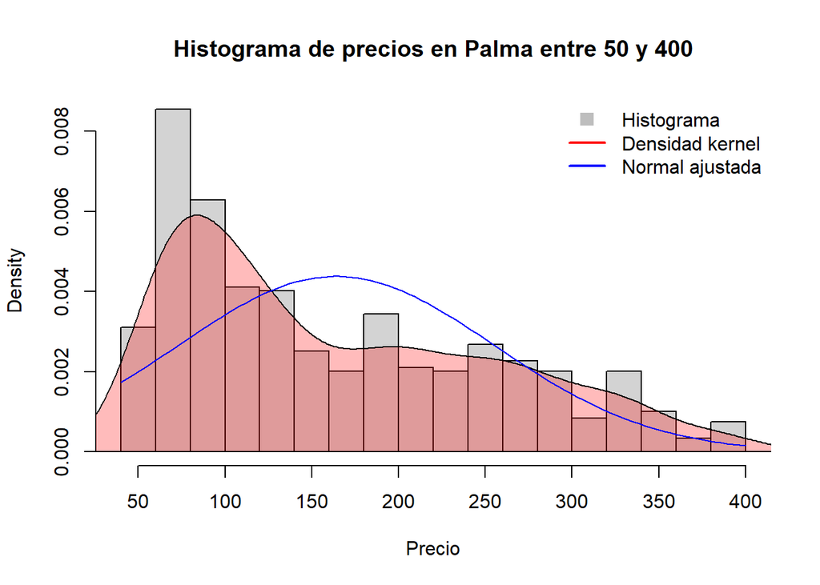

```r
load("clean_data/mallorca/listing_common0_select.RData")
df_palma = subset(listings_common0_select, date=="2024-09-13" & neighbourhood_cleansed=="Palma de Mallorca")
df_pollenca = subset(listings_common0_select, date=="2024-09-13" & neighbourhood_cleansed=="Pollença")
precios_palma = subset(df_palma, price>50 & price<400)[["price"]]
precios_pollenca = subset(df_pollenca, price>50 & price<400)[["price"]]

hist(precios_palma, freq=FALSE, xlab="Precio", main="Histograma de precios en Palma entre 50 y 400", breaks=20)
polygon(density(precios_palma), col="#ff000044")
curve(dnorm(x,mean(precios_palma),sd(precios_palma)), add=TRUE, col="blue")
legend(
  "topright",
  legend = c("Histograma", "Densidad kernel", "Normal ajustada"),
  col    = c("gray", "red", "blue"),
  lwd    = c(NA, 2, 2),
  pch    = c(15, NA, NA),
  pt.cex = 1.5,
  bty    = "n"
)
```

**Código**

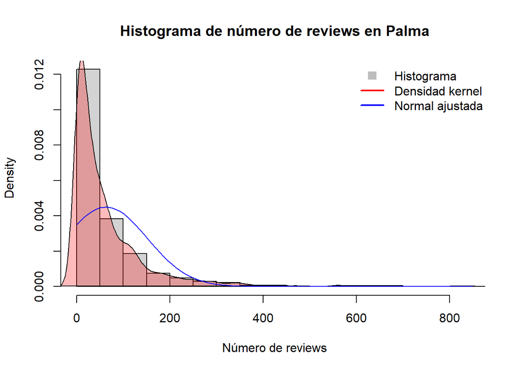

```r
hist(df_palma[["number_of_reviews"]], freq=FALSE, main="Histograma de número de reviews en Palma", xlab="Número de reviews", breaks=20)
polygon(density(df_palma[["number_of_reviews"]]), col="#ff000044")
curve(dnorm(x,mean(df_palma[["number_of_reviews"]]),sd(df_palma[["number_of_reviews"]])), add=TRUE, col="blue")
legend(
  "topright",
  legend = c("Histograma", "Densidad kernel", "Normal ajustada"),
  col    = c("gray", "red", "blue"),
  lwd    = c(NA, 2, 2),
  pch    = c(15, NA, NA),
  pt.cex = 1.5,
  bty    = "n"
)
```

**Código**

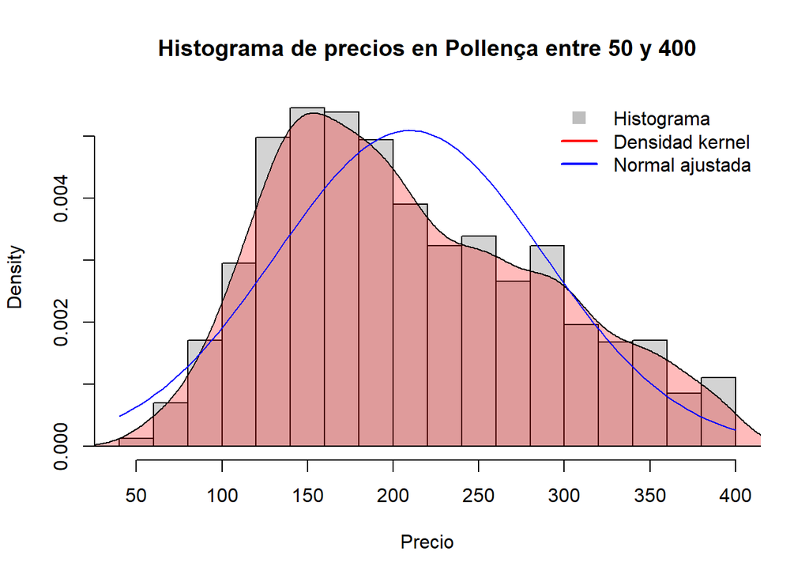

```r
hist(precios_pollenca, freq=FALSE, xlab="Precio", main="Histograma de precios en Pollença entre 50 y 400", breaks=20)
polygon(density(precios_pollenca), col="#ff000044")
curve(dnorm(x,mean(precios_pollenca),sd(precios_pollenca)), add=TRUE, col="blue")
legend(
  "topright",
  legend = c("Histograma", "Densidad kernel", "Normal ajustada"),
  col    = c("gray", "red", "blue"),
  lwd    = c(NA, 2, 2),
  pch    = c(15, NA, NA),
  pt.cex = 1.5,
  bty    = "n"
)
```

**Código**

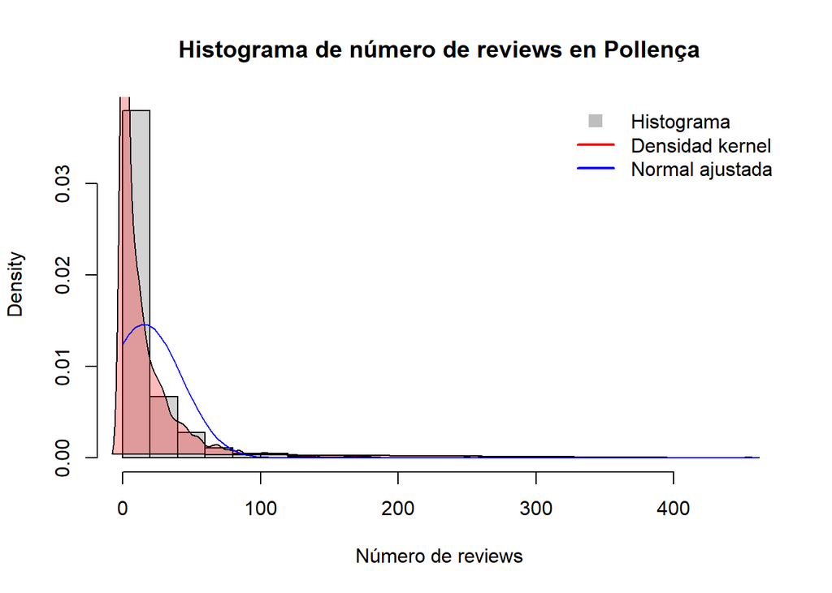

```r
hist(df_pollenca[["number_of_reviews"]], freq=FALSE, main="Histograma de número de reviews en Pollença", xlab="Número de reviews", breaks=20)
polygon(density(df_pollenca[["number_of_reviews"]]), col="#ff000044")
curve(dnorm(x,mean(df_pollenca[["number_of_reviews"]]),sd(df_pollenca[["number_of_reviews"]])), add=TRUE, col="blue")
legend(
  "topright",
  legend = c("Histograma", "Densidad kernel", "Normal ajustada"),
  col    = c("gray", "red", "blue"),
  lwd    = c(NA, 2, 2),
  pch    = c(15, NA, NA),
  pt.cex = 1.5,
  bty    = "n"
)
```

Se puede comprobar comparando el histograma y la función de densidad con la normal que corresponde a la media y desviación estándard de cada conjunto de datos que ninguna de las graficas mostradas se asemeja a una distribución normal.

## Pregunta 3 (**1punto**)

Con los datos de `listings0` de todos los periodos, contrastar si la media del precio en Alcudia es igual a la de Palma **contra** que es mayor que en Palma para los precios mayores que 50 euros y menores de 400. Construid la hipótesis nula y alternativa, calculad el $p$-valor y el intervalo de confianza asociado al contraste. Justifica técnicamente la conclusión del contraste.

### SOLUCIÓN

Planteamos las hipótesis:

$H_{0}:~~\mu_{alcudia}=\mu_{palma}$

$H_{1}:~~\mu_{alcudia}>\mu_{palma}$

Se filtran los anuncios para Palma y Alcúdia con $50<precio<400$

**Código**

```r
listings_palma = subset(listings0, neighbourhood_cleansed=="Palma de Mallorca" & price>50 & price<400)
listings_alcudia = subset(listings0, neighbourhood_cleansed=="Alcúdia" & price>50 & price<400)
mean_palma = mean(listings_palma[["price"]])
mean_alcudia = mean(listings_alcudia[["price"]])
```

$\mu_{palma}$ = 183.6372787

$\mu_{alcudia}$ = 193.9472325

Ahora se calcula el $p$-valor para determinar si se puede rechazar o no la hipótesis nula.

Estos cálculos se realizan con nivel de significación $\alpha = 0.05$

**Código**

```r
t = t.test(x = listings_alcudia["price"], y = listings_palma["price"], alternative = "greater")
p_valor = t$p.value
```

Al realizar los cálculos se puede observar que $p$-valor = 0.0000001265

Si comparamos el $p$_valor con el nivel se significación $\alpha = 0.05$ se comprueba que $1.2653046\times 10^{-7} < 0.05$ por tanto contamos con la evidencia estadística suficientes para rechazar $H_{0}$

## Pregunta 4 (**1punto**)

Con los datos de `listings0`, contrastar si las medias de los precios en Alcudia entre los periodos 2025-06-15 y 2025-09-21 son iguales contra que son menores. Construid la hipótesis nula y alternativa, calculad el $p$-valor y el intervalo de confianza asociado al contraste.

Haced un diagrama de caja comparativo de los precios en Alcudia por periodo y coméntalo.

### SOLUCIÓN

Queremos comparar los precios medios en Alcúdia entre dos períodos: 2025-06-15 y 2025-09-21.

$$\left\{\begin{array}{ll}
H_0: & \mu_{Jun} \geq \mu_{Sep}\\
H_1: & \mu_{Jun} < \mu_{Sep}
\end{array}
\right.$$

**Código**

```r
#Cargamos los dos periodos

library(tidyverse)

listings_0625 = read.csv("data/mallorca/2025-06-15/listings.csv.gz")
listings_0921 = read.csv("data/mallorca/2025-09-21/listings.csv.gz")
```

**Código**

```r
#Filtramos Alcúdia por los dos periodos
alcudia_0625 = listings_0625 %>%
  filter(neighbourhood_cleansed == "Alcúdia") %>%
  select(price) %>%
  mutate(date = as.Date("2025-06-15"))

alcudia_0921 = listings_0921 %>%
  filter(neighbourhood_cleansed == "Alcúdia") %>%
  select(price) %>%
  mutate(date = as.Date("2025-09-21"))

#Unimos los dos periodos en un solo dataset
alcudia = bind_rows(alcudia_0625, alcudia_0921)

alcudia$price = as.numeric(
  gsub("[^0-9.]", "", alcudia$price)
) #Elimina €, $, comas, espacios, es a decir, los convierte en numéricos

alcudia = alcudia %>% filter(!is.na(price)) #Eliminar posibles NA

table(alcudia$date)
```

```
2025-06-15 2025-09-21
      1566       1460
```

Mirando la teoria, podemos ver que para hacer el contraste de medias, debemos utilizar el caso estadístico VIII.

$$\left\{\begin{array}{ll}
H_0: & \mu_1 = \mu_2\\
H_1: & \mu_1 < \mu_2
\end{array}
\right.$$

$$T = \frac{\overline{X}_1 - \overline{X}_2}{\tilde{S}_{1,2}} \sim t_f$$

**Código**

```r
alcudia$date = factor(
  alcudia$date,
  levels = as.Date(c("2025-06-15", "2025-09-21"))
)

test <- t.test(
  price ~ date,
  data = alcudia,
  alternative = "less",
  conf.level = 0.95
)

test
```

```
    Welch Two Sample t-test

data:  price by date
t = 0.38722, df = 3021.7, p-value = 0.6507
alternative hypothesis: true difference in means between group 2025-06-15 and group 2025-09-21 is less than 0
95 percent confidence interval:
     -Inf 194.2569
sample estimates:
mean in group 2025-06-15 mean in group 2025-09-21
                1123.612                 1086.605
```

Para comparar las medias de los precios en Alcúdia entre los periodos 2025-06-15 y 2025-09-21, se ha utilizado un contraste t Student para dos muestras independientes con varianzas desconocidas y no necesariamente iguales (caso VIII).

A partir del contraste se obtiene un $p$-valor muy superior al 0.05, por lo que no hay evidencia estadística para rechazar la hipótesis nula. No podemos afirmar que los precios medios de los alojamientos en Alcúdia en el periodo 2025-06-15 sean menores que los del periodo 2025-09-21.

El intervalo de confianza al 95% para la diferencia de medias ($\mu_{Jun}$ - $\mu_{Sep}$) incluye valores positivos y negativos, por lo que no permite concluir que exista una diferencia significativa entre ambos periodos.

Finalmente, hacemos un diagrama de caja comparativo:

**Código**

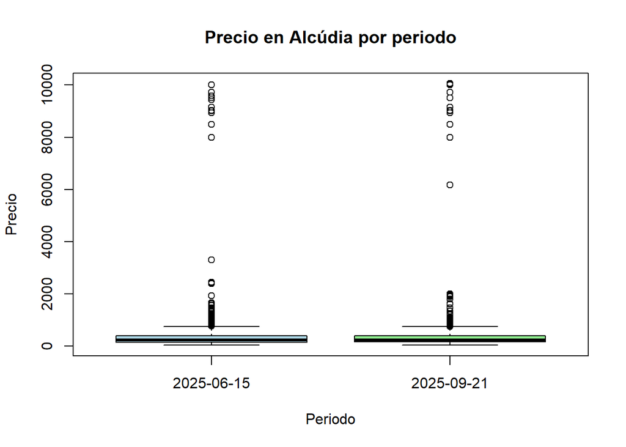

```r
boxplot(
  price~date,
  data=alcudia,
  main="Precio en Alcúdia por periodo",
  xlab="Periodo",
  ylab="Precio",
  col=c("lightblue", "lightgreen")
)
```

## Pregunta 5 (**1 punto**)

Comparar con un bopxlot de las valoraciones medias `review_scores_rating` para Alcudia, Palma, Calvià y Pollença. Hacer el gráfico con ggplot2 y todo lujo de destalles.

### SOLUCIÓN

Hemos de comparar la distribucion de las valoraciones medias entre nuestros cuatro municpios dados. Al usar el boxplot como nos dice el enunciado, podremos visualizar medianas, dispersion, asimetrias y posibles “outliers” (casos que no se ajustan a lo esperado) de cada grupo. Para comenzar, hemos de quedarnos solo con los municipios de nos interesan de nuestro set de datos. Para esto, aplicamos las funciones de filter(), que seleccionara las filas segun una condición, y %>% que sirve para encadenar operaciones de una forma mas legible.

**Código**

```r
municipios = c("Alcúdia", "Palma de Mallorca", "Calvià", "Pollença")
listings5 = listings0 %>% filter(neighbourhood_cleansed %in% municipios)
```

De forma resumida, acabamos de filtar un conjunto de datos quedandonos solo con las observaciones que pertenecen a un conjunto de categorias concretas.

A continuacion, construimos el grafico haciendo uso de ggplot2.

**Código**

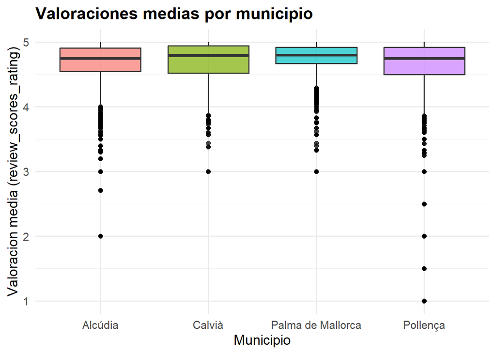

```r
ggplot(listings5,
       aes(x = neighbourhood_cleansed, y = review_scores_rating,fill = neighbourhood_cleansed))+
  geom_boxplot(alpha = 0.7, outlier.color = "black") +
  labs(title = "Valoraciones medias por municipio", x = "Municipio", y = "Valoracion media (review_scores_rating)", fill = "Municipio") +
  theme_minimal(base_size = 14) +
  theme(legend.position = "none", plot.title = element_text(face = "bold"))
```

En cuanto a funciones usadas para la creacion del grafico: - aes: srive para definir que variable corresponde con el eje de coordenadas X e Y al igual que determinar el color de esta. Es una funcion estetica.

- geom_boxplot: Seleccionamos la forma de representacion de nuestras distribuciones.
- labs, theme_minimal, theme: Sirven para añadir cosas como etiquetas y titulos, colores… En general, cada una de estas funciones sirven para añadir funciones o elementos visuales o esteticos. Al usar boxplot como nos pide el enunciado, se nos hace mas facil la comparacion por cosas como la muestra mediana, permitiendo una comparacion mas directa, la comparacion de multiples distribuciones a la vez y la señalizacion de los outliers.

**Interpretación del gráfico y Comparación entre municipios.**

Dentro de nuestro grafico, cada Municipio vendra representado por un boxplot de un color distinto cada uno. Dentro de este grafico, la lina horizontal dentro de la caja es la mediana, el valor central. La caja abarca de nuestro primer cuartil hasta el tercero, que representa el 50% central de los datos. Los bigotes, que son las barras verticales de la figura, sirven para indicar los valores que no se consideran outliers, mientras que los puntos negros fuera de estos son los outliers, con valoraciones inusualmente bajas o altas. Alcúdia presenta una mediana alta, que ronda el 4.8. Como su caja es estrecha, esto nos indica que hay una variabilidad baja. Hay una gran cantidad de outliers, la mayoria de los cuales suelen rondar puntuacions altas, pero hay un subconjunto de ellos que ronda las bajas. En cuanto a Calviá, su mediana ronda los 4.8 o 4.85, pero se diferencia de Alcúdia con una caja mas ancha, indicando una variabilidad mas alta. En cuanto a los Outliers, Calviá presenta pocos, y ademas rondan puntuaciones altas iguales o superiores al 3. Despues se tiene a Palma de Mallorca, la cual presenta una mediana similar a la de Calviá, pero con una caja mas estrecha indicando poca variabilidad, es decir, la mayoria de valoraciones suelen rondar una media de 4.8 o 4.85. Aunque tenga mas outliers, estos estan en una situacion casi identica a los de Calviá, donde rondan puntuaciones altas iguales o superiores al 3. Por ultimo, Pollença presenta una mediana similar a la de Alcúdia, pero con una caja mas ancha indicando mas variabilidad. No solo eso, sino que sus outliers estan dispersos por todo el eje Y, con valoraciones que llegan hasta el 1. En conclusion, Palma de Mallorca presenta la mediana mas alta y una disspersion relativamente baja, lo que suigere valoraciones mas consistentemente altas que las otras, pero por muy poco ya que Calviá esta en una situación similar. En tercer lugar estaria Alcúdia y por ultimo Pollença, debido a su mayor variabilidad y algunos valores extremadamente bajos.

## Pregunta 6 (**1 punto**)

Calcular la proporción de apartamentos de la muestra “2025-09-21” con media de valoración `review_scores_rating` mayor que 4 en Alcudia y en Calvià son iguales contra que son distintas. Construid un intervalo de confianza para la diferencia de proporciones.

### SOLUCIÓN

Para comprobar si las proporciones de apartamentos de valoracion mayor que 4 entre Alcúdia y Calvià son iguales, comenzamos declarando que $p_1$ representara la proporcion en Alcúdia, mientras que $p_2$ la proporcion en Calvià, ya que nos interesa su diferencia: $\hat p_1 - \hat p_2$. Declarandolo como un contraste de dos proporciones, obtenemos la siguiente hipotesis nula y alternativa: $H_0 : p_1 = p_2$ $H_1 : p_1 \ne p_2$ Establecienco nuestro nivel de significacion $\alpha = 0.05$. Si el p-valor $\geq$ 0.05, no rechazamos $H_0$, que se puede ver tambien a la hora de hacer el intervalo de confianza por si apareze el 0 o no. Comenzamos filtrando nuestros datos por fecha y municipios:

**Código**

```r
listings6 = listings0 %>% filter(
  date==as.Date("2025-09-21"),
  neighbourhood_cleansed %in% c("Alcúdia", "Calvià")
)
```

Y despues guardamos nuestras porporciones cogiendo los datos de la coleccion anteriormente creada:

**Código**

```r
props = listings6 %>%
  filter(!is.na(review_scores_rating)) %>%   # quitar NA
  group_by(neighbourhood_cleansed) %>%
  summarise(
    n = n(),                                      # n1 y n2
    x = sum(review_scores_rating > 4),            # x1 y x2
    p = mean(review_scores_rating > 4),           # p1 y p2
  )
```

x = Numero de apartamentos con rating > 4 n = numero total de apartamentos $\hat p$ = propocion $x/n$ Ahora, guardamos cada valor calculado en su respectivo lugar haciendo uso de filtros.

**Código**

```r
# Alcúdia
n1 = props$n[props$neighbourhood_cleansed == "Alcúdia"]
x1 = props$x[props$neighbourhood_cleansed == "Alcúdia"]
p1 = props$p[props$neighbourhood_cleansed == "Alcúdia"]

# Calvià
n2 = props$n[props$neighbourhood_cleansed == "Calvià"]
x2 = props$x[props$neighbourhood_cleansed == "Calvià"]
p2 = props$p[props$neighbourhood_cleansed == "Calvià"]
```

Con estos datos, somos capazes de ver que nos encontramos en el caso XIX debido a la independencia de las proporciones. Por lo que procedemos a calcular el siguiente estadistico” $\displaystyle Z=\frac{\hat p_1 - \hat p_2}{\sqrt{\hat p\hat q(\frac{1}{n_1}+\frac{1}{n_2})}}$ donde $\displaystyle \hat p = \frac{n_1\hat p_1 + n_2\hat p_2}{n_1+n_2}$ y $\hat q = 1- \hat p$.

**Código**

```r
p = ((p1*n1)+(n2*p2))/(n1+n2)
q = 1-p
Z = (p1-p2)/sqrt(p*q*((1/n1)+(1/n2)))
```

Y, con lo cual, somos capaces de calcular el p-valor haciendo uso de: $\displaystyle 2·P(Z\geq |z|)$

**Código**

```r
2*pnorm(Z, lower.tail = FALSE)
```

```
[1] 0.5843657
```

Nuestro p-valor (0.58436), nos sale superior al $\alpha = 0.05$ establecido anteriormente, por lo que no encontramos evidencia estadisticamente significativa de que las proporciones sean distintas, es decir, no rechazamos $H_0$. Por lo que acabamos viendo que las proporciones son iguales.

El intervalo de confianza para el caso XIX es $\displaystyle ]\hat p_1 - \hat p_2-z_{0.975}·\sqrt{\hat p \hat q (\frac{1}{n_1}+\frac{1}{n_2})},\hat p_1 -\hat p_2 + z_{0.975}\sqrt{\hat p \hat q (\frac{1}{n_1}+\frac{1}{n_2})}[$. Este lo podemos calcular de la siguiente forma:

**Código**

```r
c(p1-p2-qnorm(0.975)*sqrt(p*q*(1/n1+1/n2)),p1-p2+qnorm(0.975)*sqrt(p*q*(1/n1+1/n2))) #0.975 sale de hacer 1-(alpha=0.05/2)
```

```
[1] -0.02712745  0.04813214
```

Nuestro intervalo de confianza para nuestra diferencia es [-0.02712, 0.04813]. Como podemos ver, el 0 acaba estando incluido en este intervalo, con lo que podemos corroborar que no podemos descartar que las dos proporciones sean iguales, ya que no hay pruebas de una diferencia significativa. Por lo que, en conclusion, no encontramos pruebas estadisticamente significativas de que la proporcion de apartamentos con `review_scores_rating > 4` difiera entre Alcúdia y Calvià en la muestra de la fecha 21-09-2025.

## Pregunta 7 (**1punto**)

Calcular la proporción de apartamentos de los periodos 2025-06-15 y 2025-09-21 con media de valoración `review_scores_rating` mayor que 4 en Palma y en Pollença son iguales contra que son distintas.

### SOLUCIÓN

**Calculos para el periodo 2025-06-15**

Para comprobar si las proporciones de apartamentos de valoracion mayor que 4 del periodo 2025-06-15 entre Palma de Mallorca y Pollença son iguales, comenzamos declarando que $p_1$ representara la proporcion en Palma de Mallorca, mientras que $p_2$ la proporcion en Pollença, ya que nos interesa su diferencia: $\hat p_1 - \hat p_2$. Declarandolo como un contraste de dos proporciones, obtenemos la siguiente hipotesis nula y alternativa: $H_0 : p_1 = p_2$ $H_1 : p_1 \ne p_2$ Establecienco nuestro nivel de significacion $\alpha = 0.05$. Si el p-valor $\geq$ 0.05, no rechazamos $H_0$, que se puede ver tambien a la hora de hacer el intervalo de confianza por si apareze el 0 o no dentro del intervalo. Comenzamos filtrando nuestros datos por fecha y municipios:

**Código**

```r
listings7 = listings0 %>% filter(
  date==as.Date("2025-06-15"),
  neighbourhood_cleansed %in% c("Palma de Mallorca", "Pollença")
)
```

Y despues guardamos nuestras porporciones cogiendo los datos de la coleccion anteriormente creada:

**Código**

```r
props = listings7 %>%
  filter(!is.na(review_scores_rating)) %>%   # quitar NA
  group_by(neighbourhood_cleansed) %>%
  summarise(
    n = n(),                                      # n1 y n2
    x = sum(review_scores_rating > 4),            # x1 y x2
    p = mean(review_scores_rating > 4),           # p1 y p2
  )
```

x = Numero de apartamentos con rating > 4 n = numero total de apartamentos $\hat p$ = propocion $x/n$ Ahora, guardamos cada valor calculado en su respectivo lugar haciendo uso de filtros.

**Código**

```r
# Palma de Mallorca
n1 = props$n[props$neighbourhood_cleansed == "Palma de Mallorca"]
x1 = props$x[props$neighbourhood_cleansed == "Palma de Mallorca"]
p1 = props$p[props$neighbourhood_cleansed == "Palma de Mallorca"]

# Pollença
n2 = props$n[props$neighbourhood_cleansed == "Pollença"]
x2 = props$x[props$neighbourhood_cleansed == "Pollença"]
p2 = props$p[props$neighbourhood_cleansed == "Pollença"]
```

Con estos datos, somos capazes de ver que nos encontramos en el caso XIX debido a la independencia de las proporciones. Por lo que procedemos a calcular el siguiente estadistico” $\displaystyle Z=\frac{\hat p_1 - \hat p_2}{\sqrt{\hat p\hat q(\frac{1}{n_1}+\frac{1}{n_2})}}$ donde $\displaystyle \hat p = \frac{n_1\hat p_1 + n_2\hat p_2}{n_1+n_2}$ y $\hat q = 1- \hat p$.

**Código**

```r
p = ((p1*n1)+(n2*p2))/(n1+n2)
q = 1-p
Z = (p1-p2)/sqrt(p*q*((1/n1)+(1/n2)))
```

Y, con lo cual, somos capaces de calcular el p-valor haciendo uso de: $\displaystyle 2·P(Z\geq |z|)$

**Código**

```r
2*pnorm(Z, lower.tail = FALSE)
```

```
[1] 1.778238e-06
```

Nuestro p-valor (1.77824e^-06), nos sale inferior al $\alpha = 0.05$ establecido anteriormente, por lo que rechazamos nuestra hipotesis nula, aceptando la alternativa, y por lo tanto podemos decir que las proporciones entre Palma de Mallorca y Pollença son diferentes para el periodo de tiempo de 2025-06-15. Para la comparacion final entre ambos, calcularemos el intervalo de confianza del 95% usando la formula del caso XIX: $\displaystyle ]\hat p_1 - \hat p_2-z_{0.975}·\sqrt{\hat p \hat q (\frac{1}{n_1}+\frac{1}{n_2})},\hat p_1 \hat p_2 + z_{0.975}\sqrt{\hat p -\hat q (\frac{1}{n_1}+\frac{1}{n_2})}[$.

**Código**

```r
interval1 = c(p1-p2-qnorm(0.975)*sqrt(p*q*(1/n1+1/n2)),p1-p2+qnorm(0.975)*sqrt(p*q*(1/n1+1/n2))) #0.975 sale de hacer 1-(alpha=0.05/2)
```

**Calculos para el periodo 2025-09-21**

Para comprobar si las proporciones de apartamentos de valoracion mayor que 4 del periodo 2025-09-21 entre Palma de Mallorca y Pollença son iguales, comenzamos declarando que $p_1$ representara la proporcion en Palma de Mallorca, mientras que $p_2$ la proporcion en Pollença, ya que nos interesa su diferencia: $\hat p_1 - \hat p_2$. Declarandolo como un contraste de dos proporciones, obtenemos la siguiente hipotesis nula y alternativa: $H_0 : p_1 = p_2$ $H_1 : p_1 \ne p_2$ Establecienco nuestro nivel de significacion $\alpha = 0.05$. Si el p-valor $\geq$ 0.05, no rechazamos $H_0$, que se puede ver tambien a la hora de hacer el intervalo de confianza por si apareze el 0 o no dentro del intervalo. Comenzamos filtrando nuestros datos por fecha y municipios:

**Código**

```r
listings7 = listings0 %>% filter(
  date==as.Date("2025-09-21"),
  neighbourhood_cleansed %in% c("Palma de Mallorca", "Pollença")
)
```

Y despues guardamos nuestras porporciones cogiendo los datos de la coleccion anteriormente creada:

**Código**

```r
props = listings7 %>%
  filter(!is.na(review_scores_rating)) %>%   # quitar NA
  group_by(neighbourhood_cleansed) %>%
  summarise(
    n = n(),                                      # n1 y n2
    x = sum(review_scores_rating > 4),            # x1 y x2
    p = mean(review_scores_rating > 4),           # p1 y p2
  )
```

x = Numero de apartamentos con rating > 4 n = numero total de apartamentos $\hat p$ = propocion $x/n$ Ahora, guardamos cada valor calculado en su respectivo lugar haciendo uso de filtros.

**Código**

```r
# Palma de Mallorca
n1 = props$n[props$neighbourhood_cleansed == "Palma de Mallorca"]
x1 = props$x[props$neighbourhood_cleansed == "Palma de Mallorca"]
p1 = props$p[props$neighbourhood_cleansed == "Palma de Mallorca"]

# Pollença
n2 = props$n[props$neighbourhood_cleansed == "Pollença"]
x2 = props$x[props$neighbourhood_cleansed == "Pollença"]
p2 = props$p[props$neighbourhood_cleansed == "Pollença"]
```

Con estos datos, somos capazes de ver que nos encontramos en el caso XIX debido a la independencia de las proporciones. Por lo que procedemos a calcular el siguiente estadistico” $\displaystyle Z=\frac{\hat p_1 - \hat p_2}{\sqrt{\hat p\hat q(\frac{1}{n_1}+\frac{1}{n_2})}}$ donde $\displaystyle \hat p = \frac{n_1\hat p_1 + n_2\hat p_2}{n_1+n_2}$ y $\hat q = 1- \hat p$.

**Código**

```r
p = ((p1*n1)+(n2*p2))/(n1+n2)
q = 1-p
Z = (p1-p2)/sqrt(p*q*((1/n1)+(1/n2)))
```

Y, con lo cual, somos capaces de calcular el p-valor haciendo uso de: $\displaystyle 2·P(Z\geq |z|)$

**Código**

```r
2*pnorm(Z, lower.tail = FALSE)
```

```
[1] 1.762434e-06
```

Nuestro p-valor (1.762434e^-06), nos sale inferior al $\alpha = 0.05$ establecido anteriormente, por lo que rechazamos nuestra hipotesis nula, aceptando la alternativa, y por lo tanto podemos decir que las proporciones entre Palma de Mallorca y Pollença son diferentes para el periodo de tiempo de 2025-09-21. Para la comparacion final entre ambos, calcularemos el intervalo de confianza del 95% usando la formula del caso XIX: $\displaystyle ]\hat p_1 - \hat p_2-z_{0.975}·\sqrt{\hat p \hat q (\frac{1}{n_1}+\frac{1}{n_2})},\hat p_1 - \hat p_2 + z_{0.975}\sqrt{\hat p \hat q (\frac{1}{n_1}+\frac{1}{n_2})}[$.

**Código**

```r
interval2 = c(p1-p2-qnorm(0.975)*sqrt(p*q*(1/n1+1/n2)),p1-p2+qnorm(0.975)*sqrt(p*q*(1/n1+1/n2))) #0.975 sale de hacer 1-(alpha=0.05/2)
```

**Interpretacion/Comprobacion entre ambos periodos**

Entre ambos periodos, podemos ver que el p-valor del periodo 2025-06-15 es ligeramente superior al p-valor del periodo 2025-09-21. Para una vision mas detallada de lo que esta pasando, procedemos a visualizar los intervalos de confianza del 95% de ambos periodos:

**Código**

```r
#Periodo 2025-06-15
interval1
```

```
[1] 0.03738111 0.08939500
```

**Código**

```r
#Periodo 2025-09-21
interval2
```

```
[1] 0.03584266 0.08568412
```

## Pregunta 8 (**1punto**)

Agrupa las variables `review_scores_rating` y `review_scores_location` de `listings0` en 5 categorías cada una y construid una tabla de contingencia con las dos variables agrupadas. Agrupar de forma que no cruces de categorías vacías. Contratar si esta varibles son independientes con un test $\chi^2$.

Buscan información sobre el coeficiente de contingencia de Carl Pearson, cacularlo desde la salida de chisq.test interpretarlo en esta caso

**Código**

```r
table(cut(listings0$review_scores_rating,5),
      cut(listings0$review_scores_location,5))
```

```
              (0.996,1.8] (1.8,2.6] (2.6,3.4] (3.4,4.2] (4.2,5]
  (0.996,1.8]          17         8         6        10       2
  (1.8,2.6]             8        11        12        30      34
  (2.6,3.4]             8        20        59       125     168
  (3.4,4.2]             0         0       105      1217    2905
  (4.2,5]               0         9        93      2313   57567
```

### SOLUCIÓN

Generamos la tabla de contingencia para `review_scores_rating` y `review_scores_location` agrupadas en 5 categorías sin que se encuentre ninguna vacía. Para ello, se dividen los elementos únicos de cada variable en $n=5$ cuantiles, de esta forma se reduce el riesgo de que estos se repitan. Se realiza un `cut()` sobre las variables utilizando como intervalos los cuantiles obtenidos.

**Código**

```r
df <- listings0[!is.na(listings0$review_scores_rating) & !is.na(listings0$review_scores_location), ]
scores <- df$review_scores_rating
locations <- df$review_scores_location
cut_qtl = function(x, n){
  u = sort(unique(x))
  probs = seq(0, 1, length.out = n+1)
  q = quantile(u, probs = probs, type = 1)
  cut(x, q, include.lowest=TRUE)
}
tab <- table(cut_qtl(scores, 5), cut_qtl(locations, 5))
tab
```

```
              [1,3.79] (3.79,4.12] (4.12,4.42] (4.42,4.71] (4.71,5]
  [1,3.73]         238         244         122         180      182
  (3.73,4.07]      204         701         324         519      923
  (4.07,4.39]       81         322         834        1641     1416
  (4.39,4.69]       67         505        1723        5568     5987
  (4.69,5]         170         883        1347        9290    31256
```

Realizamos el test $\chi^2$

**Código**

```r
chq = chisq.test(tab)
chq
```

```
    Pearson's Chi-squared test

data:  tab
X-squared = 17750, df = 16, p-value < 2.2e-16
```

Se puede observar que el $p$-valor es un número muy inferior a 0.05 con lo cual se concluye que las variables son dependientes.

El coeficiente de contingencia de Pearson es un valor entre 0 y 1 que calcula la asociación estadística entre dos variables cualitativas, y cuanto mayor es su valor más fuertemente están relacionadas las variables. Se calcula mediante la formula $\sqrt{\frac{\chi^2}{\chi^2+n}}$

**Código**

```r
pearson <- sqrt(chq$statistic / (chq$statistic + sum(tab)))
```

En este caso el coeficiente de contingencia de Pearson es 0.4639108 lo que indica una intensidad de asociación moderada.

## Pregunta 9 (**3 puntos**)

Construye un data set con las variables review_scores_rating, review_scores_cleanliness, review_scores_location, review_scores_value de listings0 y el municipio/zona `neighbourhood_cleansed`

Calcula la matriz de correlaciones entre estas variables y haz un gráfico de pares de variables que muestre las correlaciones ([ggpairs](https://r-charts.com/correlation/ggpairs/)) con la librería GGally. Comenta los resultados.

Haz un `matrixplot` de las correlaciones con la librería `corrplot`. Comenta los resultados.

### SOLUCIÓN

Construimos el data set con las variables indicadas y mostramos las primeras filas, poniendo el municipio en la primera columna para mejor visualización:

**Código**

```r
datos_scores <- listings0 %>%
  select(
    neighbourhood_cleansed,
    review_scores_rating,
    review_scores_cleanliness,
    review_scores_location,
    review_scores_value
  )
head(datos_scores)
```

```
# A tibble: 6 × 5
  neighbourhood_cleansed review_scores_rating review_scores_cleanliness
  <chr>                                 <dbl>                     <dbl>
1 Santanyí                              NA                        NA
2 Felanitx                              NA                        NA
3 Felanitx                               4.89                      4.89
4 Felanitx                              NA                        NA
5 Alcúdia                               NA                        NA
6 Valldemossa                            4.73                      4.59
# ℹ 2 more variables: review_scores_location <dbl>, review_scores_value <dbl>
```

Calculamos la matriz de correlaciones de las variables numéricas (puntuaciones del 0 al 5) y generamos el gráfico de pares de variables con la librería GGally:

**Código**

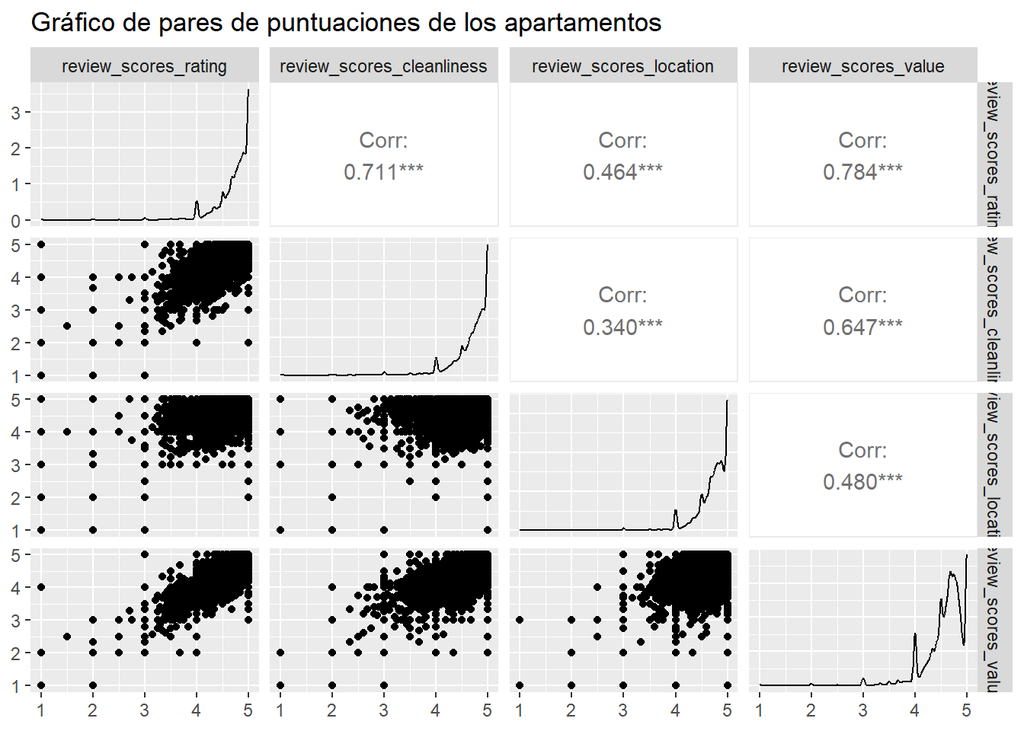

```r
# Calculamos la matriz
variables_numericas <- datos_scores %>%
  select(
    review_scores_rating,
    review_scores_cleanliness,
    review_scores_location,
    review_scores_value
  )
matriz_correlaciones <- cor(variables_numericas, use = "pairwise.complete.obs")

# Generamos el gráfico
library(GGally)
ggpairs(variables_numericas,
        title = "Gráfico de pares de puntuaciones de los apartamentos")
```

En la diagonal del gráfico se observan las distribuciones individuales (densidad) de cada variable. En el triángulo superior, se pueden observar los coeficientes de correlación cuya significancia se indica con los asteriscos (***) de la misma forma que al calcular el p-valor con un test. En el triángulo inferior, se tienen los gráficos de dispersión entre pares de variables.

De los coeficientes de correlación se puede decir que la localización de los apartamentos es la que menos influye en la puntuación global (rating), siendo la calidad (value) la más influyente de las analizadas. También se puede ver la relación entre una buena puntuación en limpieza (cleanliness) y una buena puntuación en calidad, que sugiere que la percepción de la calidad de un apartamento limpio es mucho mayor que la de un apartamento con más suciedad. Las dos variables de puntuación con menos relación entre sí son la limpieza y la localización, cuya independencia es lógica, puesto que no influyen mucho la una en la otra.

Estas relaciones pueden observarse en los gráficos de dispersión de forma visual. La relación fuerte entre la puntuación global, la limpieza y la calidad es representada mediante una nube centrada en la diagonal, lo que sugiere que las puntuaciones en las tres categorías indicadas son similares entre sí, siendo la calidad la diagonal más visible y, por tanto, la más influyente. En cambio, el gráfico que relaciona la puntuación global con la localización es más disperso, lo que sugiere una menor relación entre ambas. De hecho, los gráficos que relacionan la localización son los menos lineales, lo que refuerza la afirmación anterior: es la variable menos influyente.

Por lo tanto, se puede concluir que la puntuación global se ve muy influida por la limpieza y la calidad del apartamento y no tanto por la localización, cuyo valor no puede mejorarse de la misma forma que la limpieza y la calidad sí pueden. Todas las correlaciones son positivas y significativas, por lo que se puede deducir que los huéspedes tienden a puntuar las cuatro categorías de forma similar.

Generamos un `matrixplot` de las correlaciones:

**Código**

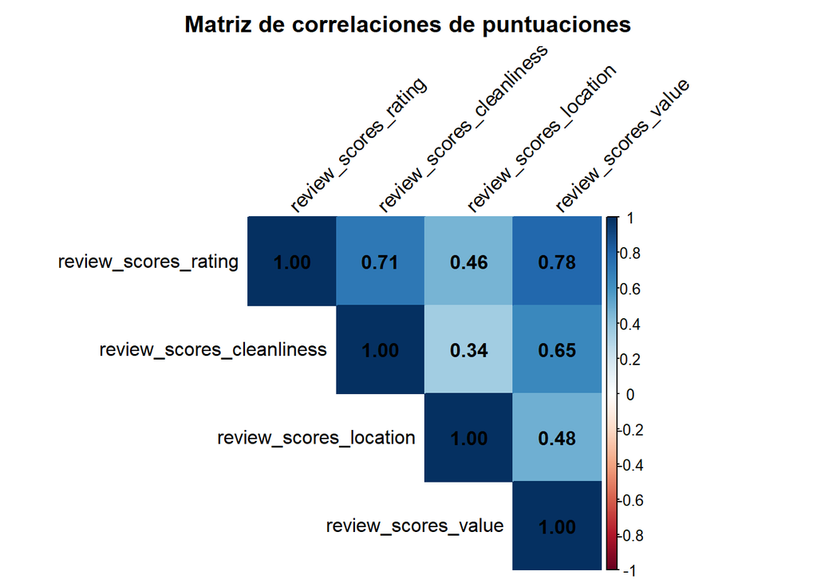

```r
library(corrplot)
corrplot(
  matriz_correlaciones,
  method = "color",
  type = "upper",
  addCoef.col = "black",
  tl.col = "black",
  tl.srt = 45,
  title = "Matriz de correlaciones de puntuaciones",
  mar = c(0,0,2,0)
)
```

Los valores en colores azules más oscuros indican una mayor correlación entre un par de variables, siendo la puntuación en una escala del -1 al 1, ambos inclusive.

Este gráfico refuerza las afirmaciones realizadas anteriormente, recalcando la fuerte relación entre la puntuación global, la limpieza y la calidad de un apartamento y la menor influencia de la puntuación de la localización en todas las demás variables.

En conclusión, la limpieza influye en la calidad y ambas influyen en la puntuación global, siendo la localización la menos influyente de las cuatro. Por lo tanto, los anfitriones podrían mejorar significativamente su puntuación global mejorando, si fuera posible, la limpieza y la calidad de los apartamentos.

## Pregunta 10 (**2 puntos**)

La [Zipf’s law es una ley empírica](https://en.wikipedia.org/wiki/Zipf%27s_law#Word_frequencies_in_natural_languages) que dice que la frecuencia de las palabras en un texto es inversamente proporcional a su rango. Decidid si la ley se ajusta a los datos de la longitud de los comentarios de los apartamentos de la muestra “2025-09-21” Mallorca, haced lo mismo para description de `listings0`. Para ello, haced un análisis de regresión lineal de la frecuencia de las longitudes de los comentarios/descripciones de los apartamentos de Mallorca y el rango de las longitudes de los comentarios. Justificad la respuesta, estadísticamente y gráficamente.

Como ayuda estudiar el siguiente código, utilizadlo y comentadlo.

**Código**

```r
library(stringr)
# para las reseñas
head(reviews)
```

```
# A tibble: 6 × 6
  listing_id      id date       reviewer_id reviewer_name comments
       <dbl>   <dbl> <date>           <dbl> <chr>         <chr>
1      69998  881474 2012-01-24     1595616 Jean-Pierre   "This place was charm…
2      69998 4007103 2013-04-02     3868130 Jo And Mike   "We had a four night …
3      69998 4170371 2013-04-15     5730759 Elizabeth     "Lor's apartment look…
4      69998 4408459 2013-05-03     5921885 Jone          "Wonderful place! 10/…
5      69998 4485779 2013-05-07      810469 Andrea        "My boyfriend and I, …
6      69998 4619699 2013-05-15     3318059 Devii         "We had a very last m…
```

**Código**

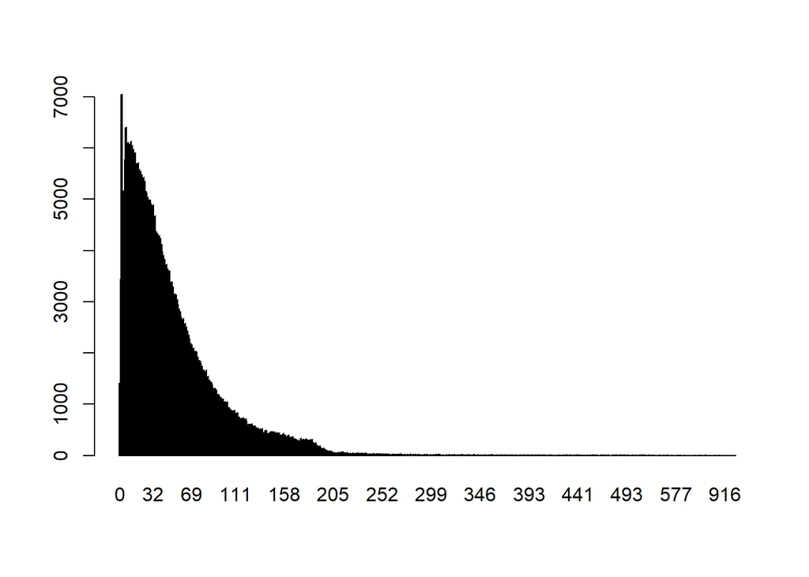

```r
length_rewiews=stringr::str_count(reviews$comments,"\\w+")
barplot(table(length_rewiews))
```

**Código**

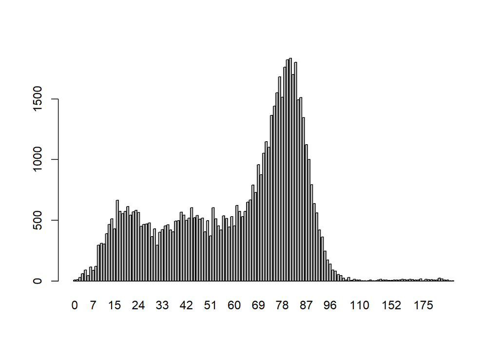

```r
#para las descripciones
length_description=stringr::str_count(listings0$description,"\\w+")
barplot(table(length_description))
```

Y ahora se calculan los rango os lo dejo para reviews para description lo haceís vosotros

**Código**

```r
aux=table(length_rewiews)
head(aux)
```

```
length_rewiews
   0    1    2    3    4    5
1418 3444 7045 4221 5165 5776
```

**Código**

```r
head(names(aux))
```

```
[1] "0" "1" "2" "3" "4" "5"
```

**Código**

```r
tbl=tibble( L=as.numeric(names(aux)),Freq=as.numeric(aux),
            Rank=rank(L),Log_Freq=log(Freq),Log_Rank=log(Rank))
str(tbl)
```

```
tibble [592 × 5] (S3: tbl_df/tbl/data.frame)
 $ L       : num [1:592] 0 1 2 3 4 5 6 7 8 9 ...
 $ Freq    : num [1:592] 1418 3444 7045 4221 5165 ...
 $ Rank    : num [1:592] 1 2 3 4 5 6 7 8 9 10 ...
 $ Log_Freq: num [1:592] 7.26 8.14 8.86 8.35 8.55 ...
 $ Log_Rank: num [1:592] 0 0.693 1.099 1.386 1.609 ...
```

**Código**

```r
tbl2=tbl %>% filter(Rank>10) %>% filter(Rank<1000)
sol1=lm(tbl2$Freq~tbl2$Rank)
summary(sol1)
```

```
Call:
lm(formula = tbl2$Freq ~ tbl2$Rank)

Residuals:
    Min      1Q  Median      3Q     Max
-1031.8  -786.9  -201.4   452.6  4046.6

Coefficients:
             Estimate Std. Error t value Pr(>|t|)
(Intercept) 2141.9530    85.2279   25.13   <2e-16 ***
tbl2$Rank     -5.1260     0.2469  -20.76   <2e-16 ***
---
Signif. codes:  0 '***' 0.001 '**' 0.01 '*' 0.05 '.' 0.1 ' ' 1

Residual standard error: 1001 on 580 degrees of freedom
Multiple R-squared:  0.4263,    Adjusted R-squared:  0.4253
F-statistic: 430.9 on 1 and 580 DF,  p-value: < 2.2e-16
```

**Código**

```r
sol2=lm(tbl2$Freq~tbl2$Log_Rank)
summary(sol2)
```

```
Call:
lm(formula = tbl2$Freq ~ tbl2$Log_Rank)

Residuals:
    Min      1Q  Median      3Q     Max
-896.17 -547.03    7.73  443.85 1629.79

Coefficients:
              Estimate Std. Error t value Pr(>|t|)
(Intercept)    8267.68     162.94   50.74   <2e-16 ***
tbl2$Log_Rank -1405.73      29.51  -47.63   <2e-16 ***
---
Signif. codes:  0 '***' 0.001 '**' 0.01 '*' 0.05 '.' 0.1 ' ' 1

Residual standard error: 596.2 on 580 degrees of freedom
Multiple R-squared:  0.7964,    Adjusted R-squared:  0.796
F-statistic:  2269 on 1 and 580 DF,  p-value: < 2.2e-16
```

**Código**

```r
sol3=lm(tbl2$Log_Freq~tbl2$Log_Rank)
summary(sol3)
```

```
Call:
lm(formula = tbl2$Log_Freq ~ tbl2$Log_Rank)

Residuals:
    Min      1Q  Median      3Q     Max
-4.3152 -0.5008  0.0081  0.5191  1.6510

Coefficients:
              Estimate Std. Error t value Pr(>|t|)
(Intercept)   20.58666    0.24105   85.40   <2e-16 ***
tbl2$Log_Rank -3.15950    0.04366  -72.36   <2e-16 ***
---
Signif. codes:  0 '***' 0.001 '**' 0.01 '*' 0.05 '.' 0.1 ' ' 1

Residual standard error: 0.882 on 580 degrees of freedom
Multiple R-squared:  0.9003,    Adjusted R-squared:  0.9001
F-statistic:  5237 on 1 and 580 DF,  p-value: < 2.2e-16
```

### SOLUCIÓN

Gráfico Zipf(log-log) para las reviews:

**Código**

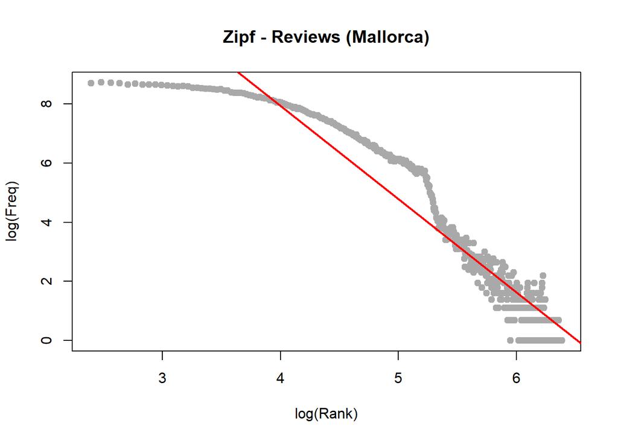

```r
plot(tbl2$Log_Rank, tbl2$Log_Freq, main = "Zipf - Reviews (Mallorca)", xlab = "log(Rank)", ylab = "log(Freq)", pch = 19, col = "darkgray")
abline(sol3, col = "red", lwd = 2)
```

Análisis para description:

**Código**

```r
aux_d = table(length_description)
tbl_d = tibble(L=as.numeric(names(aux_d)), Freq=as.numeric(aux_d), Rank=rank(L), Log_Freq=log(Freq), Log_Rank=log(Rank))


tbl_d2=tbl_d %>% filter(Rank > 10, Rank < 1000)

sol_d = lm(tbl_d2$Log_Freq ~ tbl_d2$Log_Rank)
summary(sol_d)
```

```
Call:
lm(formula = tbl_d2$Log_Freq ~ tbl_d2$Log_Rank)

Residuals:
    Min      1Q  Median      3Q     Max
-3.8352 -1.3976 -0.1771  1.3056  3.0703

Coefficients:
                Estimate Std. Error t value Pr(>|t|)
(Intercept)      13.2490     0.9782  13.545  < 2e-16 ***
tbl_d2$Log_Rank  -1.9913     0.2317  -8.596 2.16e-14 ***
---
Signif. codes:  0 '***' 0.001 '**' 0.01 '*' 0.05 '.' 0.1 ' ' 1

Residual standard error: 1.726 on 131 degrees of freedom
Multiple R-squared:  0.3607,    Adjusted R-squared:  0.3558
F-statistic:  73.9 on 1 and 131 DF,  p-value: 2.158e-14
```

Gráfico Zipf para descriptions:

**Código**

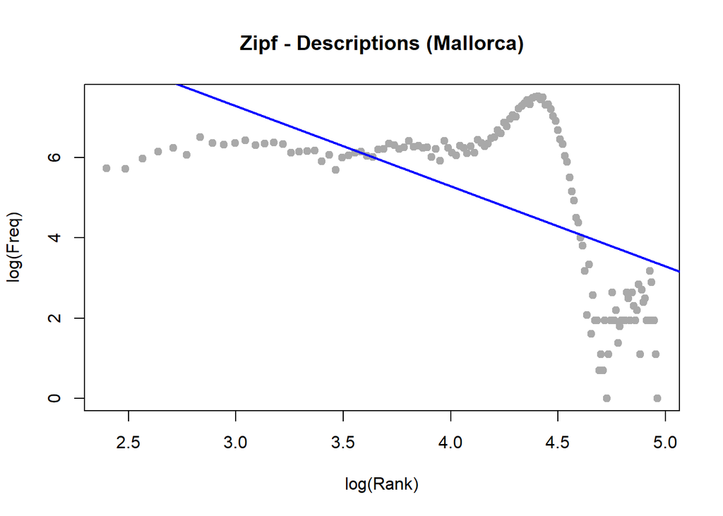

```r
plot(tbl_d2$Log_Rank, tbl_d2$Log_Freq, main="Zipf - Descriptions (Mallorca)", xlab="log(Rank)", ylab="log(Freq)", pch=19, col="darkgray")

abline(sol_d, col="blue", lwd=2)
```

Para analizar si los datos se ajustan a la ley de Zipf, se ha estudiado la relación entre la frecuencia de las longitudes de los comentarios y descripciones de los apartamentos en Mallorca y su rango. Según la ley de Zipf, esta relación debe seguir un patrón potencial, lo que implica una relación lineal entre log(Freq) y log(Rank).